# Capstone Project - Predicting the Severity of Accidents

# Applied Data Science Capstone by IBM/Coursera

# Stefanie Welcker

- Introduction: Business Problem
- Data
- Methodology
  - Data Analysis
  - Predictive Modeling
- Discussion
- Conclusion

## Introduction: Business Problem

### Background

In and around big cities with many inhabitants and many commuters, such as Seattle, accidents happen year-round. Sometimes accidents are severe and roads are blocked completely to rescue the injured, but even accidents with only propriety damage can cause traffic jams. It would be beneficial to have some warning beforehand so some areas could be bypassed.

### Problem

This study aims to investigate whether the severity of an accident can be predicted on the basis of historical data including location, weather condition, light condition, road condition and others using supervised machine leaning.

### Interest

Possible interested parties for the data can be local rescue stations, which can plan the rescue forces for example on the basis of local and weather forecasts. Better planning can both reduce costs and save lives by having the right resources readily available.

Another interested party could be radio stations, which can offer their listeners a forecast, either on traffic radio or on an online platform. This may increase the radio stations’ income generated by advertisements due more listeners or clicks on a platform. Insurances can also have an interest in the data because they may be able to forecast costs based on the expected severity of an accident.

## Data

The city of Seattle provides data on collisions [here](https://data-seattlecitygis.opendata.arcgis.com/datasets/5b5c745e0f1f48e7a53acec63a0022ab_0/data), a detailed description of the data is available [here](https://www.seattle.gov/Documents/Departments/SDOT/GIS/Collisions_OD.pdf). The data is updated every week.

### Data Cleaning and Preparation

The data covers several years of information starting at 2004-01-01 until 2020-07-29 at the time data was retrieved. Overall the original data has forty columns and 221266 rows, the `SEVERITYCODE` represents the label to be predicted, thirty nine columns are possible features.

To clean the data, missing values in estimators weather, light condition and road condition were first filled with “Unknown” and subsequently deleted together with the unknown specification “Others” because the data set is biased in favor of minor accidents and most of the “unknown” features occurred in minor accidents.

```python
# Suppress warnings of questionable usefulness.
import warnings
warnings.filterwarnings("ignore")

import pandas as pd
import numpy as np
```

```python
#import data
df2=pd.read_csv("/home/steffi/Documents/Collisions_seattle.csv")
```

```python
df2.head()
```

|  | X | Y | OBJECTID | INCKEY | COLDETKEY | REPORTNO | STATUS | ADDRTYPE | INTKEY | LOCATION | ... | ROADCOND | LIGHTCOND | PEDROWNOTGRNT | SDOTCOLNUM | SPEEDING | ST_COLCODE | ST_COLDESC | SEGLANEKEY | CROSSWALKKEY | HITPARKEDCAR |
| --- | --- | --- | --- | --- | --- | --- | --- | --- | --- | --- | --- | --- | --- | --- | --- | --- | --- | --- | --- | --- | --- |
| 0 | -122.386772 | 47.564720 | 1 | 326234 | 327734 | E984735 | Matched | Intersection | 31893.0 | CALIFORNIA AVE SW AND SW GENESEE ST | ... | Dry | Daylight | Y | NaN | NaN | 2 | Vehicle turning left hits pedestrian | 0 | 0 | N |
| 1 | -122.341806 | 47.686934 | 2 | 326246 | 327746 | E985430 | Matched | Intersection | 24228.0 | STONE AVE N AND N 80TH ST | ... | Wet | Dark - Street Lights On | NaN | NaN | NaN | 10 | Entering at angle | 0 | 0 | N |
| 2 | -122.374899 | 47.668666 | 3 | 329254 | 330754 | EA16720 | Matched | Block | NaN | NW MARKET ST BETWEEN 14TH AVE NW AND 15TH AVE NW | ... | Dry | Daylight | NaN | NaN | NaN | 11 | From same direction - both going straight - bo... | 0 | 0 | N |
| 3 | -122.300758 | 47.683047 | 4 | 21200 | 21200 | 1227970 | Matched | Intersection | 24661.0 | 25TH AVE NE AND NE 75TH ST | ... | Wet | Dark - Street Lights On | NaN | 4160038.0 | NaN | 28 | From opposite direction - one left turn - one ... | 0 | 0 | N |
| 4 | -122.313053 | 47.567241 | 5 | 17000 | 17000 | 1793348 | Unmatched | Block | NaN | S DAKOTA ST BETWEEN 15TH AVE S AND 16TH AVE S | ... | NaN | NaN | NaN | 4289025.0 | NaN | NaN | NaN | 0 | 0 | N |

5 rows × 40 columns

```python
df2.columns
```

```
Index(['X', 'Y', 'OBJECTID', 'INCKEY', 'COLDETKEY', 'REPORTNO', 'STATUS',
       'ADDRTYPE', 'INTKEY', 'LOCATION', 'EXCEPTRSNCODE', 'EXCEPTRSNDESC',
       'SEVERITYCODE', 'SEVERITYDESC', 'COLLISIONTYPE', 'PERSONCOUNT',
       'PEDCOUNT', 'PEDCYLCOUNT', 'VEHCOUNT', 'INJURIES', 'SERIOUSINJURIES',
       'FATALITIES', 'INCDATE', 'INCDTTM', 'JUNCTIONTYPE', 'SDOT_COLCODE',
       'SDOT_COLDESC', 'INATTENTIONIND', 'UNDERINFL', 'WEATHER', 'ROADCOND',
       'LIGHTCOND', 'PEDROWNOTGRNT', 'SDOTCOLNUM', 'SPEEDING', 'ST_COLCODE',
       'ST_COLDESC', 'SEGLANEKEY', 'CROSSWALKKEY', 'HITPARKEDCAR'],
      dtype='object')
```

```python
df2.dtypes
```

```
X                  float64
Y                  float64
OBJECTID             int64
INCKEY               int64
COLDETKEY            int64
REPORTNO            object
STATUS              object
ADDRTYPE            object
INTKEY             float64
LOCATION            object
EXCEPTRSNCODE       object
EXCEPTRSNDESC       object
SEVERITYCODE        object
SEVERITYDESC        object
COLLISIONTYPE       object
PERSONCOUNT          int64
PEDCOUNT             int64
PEDCYLCOUNT          int64
VEHCOUNT             int64
INJURIES             int64
SERIOUSINJURIES      int64
FATALITIES           int64
INCDATE             object
INCDTTM             object
JUNCTIONTYPE        object
SDOT_COLCODE       float64
SDOT_COLDESC        object
INATTENTIONIND      object
UNDERINFL           object
WEATHER             object
ROADCOND            object
LIGHTCOND           object
PEDROWNOTGRNT       object
SDOTCOLNUM         float64
SPEEDING            object
ST_COLCODE          object
ST_COLDESC          object
SEGLANEKEY           int64
CROSSWALKKEY         int64
HITPARKEDCAR        object
dtype: object
```

```python
# select features for cleaning
df3=df2[['SEVERITYCODE','X','Y','WEATHER','ROADCOND', 'LIGHTCOND', 'JUNCTIONTYPE', 'SPEEDING', 'PERSONCOUNT', 'VEHCOUNT', 'INCDATE']]
```

```python
df3.head()
```

|  | SEVERITYCODE | X | Y | WEATHER | ROADCOND | LIGHTCOND | JUNCTIONTYPE | SPEEDING | PERSONCOUNT | VEHCOUNT | INCDATE |
| --- | --- | --- | --- | --- | --- | --- | --- | --- | --- | --- | --- |
| 0 | 2 | -122.386772 | 47.564720 | Clear | Dry | Daylight | At Intersection (intersection related) | NaN | 2 | 1 | 2019/11/20 00:00:00+00 |
| 1 | 2 | -122.341806 | 47.686934 | Raining | Wet | Dark - Street Lights On | At Intersection (intersection related) | NaN | 4 | 2 | 2019/11/18 00:00:00+00 |
| 2 | 1 | -122.374899 | 47.668666 | Clear | Dry | Daylight | Mid-Block (not related to intersection) | NaN | 4 | 3 | 2020/02/20 00:00:00+00 |
| 3 | 1 | -122.300758 | 47.683047 | Raining | Wet | Dark - Street Lights On | At Intersection (intersection related) | NaN | 2 | 2 | 2004/06/08 00:00:00+00 |
| 4 | 0 | -122.313053 | 47.567241 | NaN | NaN | NaN | Mid-Block (but intersection related) | NaN | 0 | 0 | 2004/10/15 00:00:00+00 |

```python
df3.describe()
```

|  | X | Y | PERSONCOUNT | VEHCOUNT |
| --- | --- | --- | --- | --- |
| count | 213797.000000 | 213797.000000 | 221266.000000 | 221266.000000 |
| mean | -122.330752 | 47.620205 | 2.226230 | 1.728544 |
| std | 0.030054 | 0.056040 | 1.470364 | 0.831224 |
| min | -122.419091 | 47.495573 | 0.000000 | 0.000000 |
| 25% | -122.349280 | 47.577302 | 2.000000 | 2.000000 |
| 50% | -122.330348 | 47.616053 | 2.000000 | 2.000000 |
| 75% | -122.311998 | 47.664290 | 3.000000 | 2.000000 |
| max | -122.238949 | 47.734142 | 93.000000 | 15.000000 |

```python
# find missing data
dat_missing = df3.isnull()
```

```python
dat_missing.head()
```

|  | SEVERITYCODE | X | Y | WEATHER | ROADCOND | LIGHTCOND | JUNCTIONTYPE | SPEEDING | PERSONCOUNT | VEHCOUNT | INCDATE |
| --- | --- | --- | --- | --- | --- | --- | --- | --- | --- | --- | --- |
| 0 | False | False | False | False | False | False | False | True | False | False | False |
| 1 | False | False | False | False | False | False | False | True | False | False | False |
| 2 | False | False | False | False | False | False | False | True | False | False | False |
| 3 | False | False | False | False | False | False | False | True | False | False | False |
| 4 | False | False | False | True | True | True | False | True | False | False | False |

```python
for column in dat_missing.columns.values.tolist():
    print(column)
    print (dat_missing[column].value_counts())
    print("")
```

```
SEVERITYCODE
False    221265
True          1
Name: SEVERITYCODE, dtype: int64

X
False    213797
True       7469
Name: X, dtype: int64

Y
False    213797
True       7469
Name: Y, dtype: int64

WEATHER
False    194578
True      26688
Name: WEATHER, dtype: int64

ROADCOND
False    194658
True      26608
Name: ROADCOND, dtype: int64

LIGHTCOND
False    194490
True      26776
Name: LIGHTCOND, dtype: int64

JUNCTIONTYPE
False    209299
True      11967
Name: JUNCTIONTYPE, dtype: int64

SPEEDING
True     211353
False      9913
Name: SPEEDING, dtype: int64

PERSONCOUNT
False    221266
Name: PERSONCOUNT, dtype: int64

VEHCOUNT
False    221266
Name: VEHCOUNT, dtype: int64

INCDATE
False    221266
Name: INCDATE, dtype: int64
```

```python
#replace missing values with unknown
df3['WEATHER'].fillna("Unknown", inplace=True)
df3['ROADCOND'].fillna("Unknown", inplace=True)
df3['LIGHTCOND'].fillna("Unknown", inplace=True)
df3['JUNCTIONTYPE'].fillna("Unknown", inplace=True)
```

```python
#reclassify SPEEDING
df3['SPEEDING'].replace(to_replace=['Y'], value=[1],inplace=True)
df3['SPEEDING'].fillna(0, inplace=True)
```

```python
#checking for missing values
```

```python
dat2_missing = df3.isnull()
```

```python
for column in dat2_missing.columns.values.tolist():
    print(column)
    print (dat2_missing[column].value_counts())
    print("")
```

```
SEVERITYCODE
False    221265
True          1
Name: SEVERITYCODE, dtype: int64

X
False    213797
True       7469
Name: X, dtype: int64

Y
False    213797
True       7469
Name: Y, dtype: int64

WEATHER
False    221266
Name: WEATHER, dtype: int64

ROADCOND
False    221266
Name: ROADCOND, dtype: int64

LIGHTCOND
False    221266
Name: LIGHTCOND, dtype: int64

JUNCTIONTYPE
False    221266
Name: JUNCTIONTYPE, dtype: int64

SPEEDING
False    221266
Name: SPEEDING, dtype: int64

PERSONCOUNT
False    221266
Name: PERSONCOUNT, dtype: int64

VEHCOUNT
False    221266
Name: VEHCOUNT, dtype: int64

INCDATE
False    221266
Name: INCDATE, dtype: int64
```

```python
# checking severity code: 0 is unknown ;1=propierty damage 2, 2b and 3 seevere injuries or fatal
df3['SEVERITYCODE'].value_counts()
```

```
1     137485
2      58698
0      21635
2b      3098
3        349
Name: SEVERITYCODE, dtype: int64
```

```python
# prepare the one with missing value in row to delete later on values =0
df3['SEVERITYCODE'].fillna("0", inplace=True)
```

```python
df3.dtypes
```

```
SEVERITYCODE     object
X               float64
Y               float64
WEATHER          object
ROADCOND         object
LIGHTCOND        object
JUNCTIONTYPE     object
SPEEDING        float64
PERSONCOUNT       int64
VEHCOUNT          int64
INCDATE          object
dtype: object
```

```python
#reclassify SEVERITYCODE
df3['SEVERITYCODE'].replace(to_replace=['2b'], value=['2'],inplace=True)
df3['SEVERITYCODE'].replace(to_replace=['3'], value=['2'],inplace=True)
```

```python
df3['SEVERITYCODE'].value_counts()
```

```
1    137485
2     62145
0     21636
Name: SEVERITYCODE, dtype: int64
```

```python
#drop all rows with severity code =='0' since this is the label for prediction
df3.drop(df3[df3['SEVERITYCODE'] =='0'].index, inplace = True)
```

```python
df3.shape
```

```
(199630, 11)
```

```python
df3['SEVERITYCODE'].value_counts()
```

```
1    137485
2     62145
Name: SEVERITYCODE, dtype: int64
```

```python
dat3_missing = df3.isnull()
for column in dat3_missing.columns.values.tolist():
    print(column)
    print (dat3_missing[column].value_counts())
    print("")
```

```
SEVERITYCODE
False    199630
Name: SEVERITYCODE, dtype: int64

X
False    194228
True       5402
Name: X, dtype: int64

Y
False    194228
True       5402
Name: Y, dtype: int64

WEATHER
False    199630
Name: WEATHER, dtype: int64

ROADCOND
False    199630
Name: ROADCOND, dtype: int64

LIGHTCOND
False    199630
Name: LIGHTCOND, dtype: int64

JUNCTIONTYPE
False    199630
Name: JUNCTIONTYPE, dtype: int64

SPEEDING
False    199630
Name: SPEEDING, dtype: int64

PERSONCOUNT
False    199630
Name: PERSONCOUNT, dtype: int64

VEHCOUNT
False    199630
Name: VEHCOUNT, dtype: int64

INCDATE
False    199630
Name: INCDATE, dtype: int64
```

```python
# Clean location information:drop whole row with NaN coordinates
df3.dropna(subset=["X","Y"], axis=0, inplace=True)

# reset index, because we dropped several rows by now.
df3.reset_index(drop=True, inplace=True)
```

```python
#look at imbalance in dataset
df3['SEVERITYCODE'].value_counts()
```

```
1    133215
2     61013
Name: SEVERITYCODE, dtype: int64
```

```python
# deal with unknown values in weather, light condition road condition
```

```python
df3['WEATHER'].value_counts()
```

```
Clear                       112133
Raining                      32882
Overcast                     27919
Unknown                      18833
Snowing                        906
Other                          794
Fog/Smog/Smoke                 561
Sleet/Hail/Freezing Rain       115
Blowing Sand/Dirt               50
Severe Crosswind                25
Partly Cloudy                    9
Blowing Snow                     1
Name: WEATHER, dtype: int64
```

```python
df3['ROADCOND'].value_counts()
```

```
Dry               125681
Wet                47290
Unknown            18714
Ice                 1198
Snow/Slush           999
Other                121
Standing Water       106
Sand/Mud/Dirt         66
Oil                   53
Name: ROADCOND, dtype: int64
```

```python
df3['LIGHTCOND'].value_counts()
```

```
Daylight                    116575
Dark - Street Lights On      48830
Unknown                      17468
Dusk                          5946
Dawn                          2517
Dark - No Street Lights       1487
Dark - Street Lights Off      1189
Other                          196
Dark - Unknown Lighting         20
Name: LIGHTCOND, dtype: int64
```

```python
df3['JUNCTIONTYPE'].value_counts()
```

```
Mid-Block (not related to intersection)              89534
At Intersection (intersection related)               64715
Mid-Block (but intersection related)                 22738
Driveway Junction                                    10758
Unknown                                               4235
At Intersection (but not related to intersection)     2101
Ramp Junction                                          147
Name: JUNCTIONTYPE, dtype: int64
```

```python
# how many rows are not defined?
df3[(df3.WEATHER == 'Unknown') | (df3.LIGHTCOND == 'Unknown') | (df3.ROADCOND == 'Unknown')| (df3.WEATHER == 'Other')|(df3.LIGHTCOND == 'Other')|(df3.ROADCOND == 'Other') | (df3.JUNCTIONTYPE == 'Unknown')].count()
```

```
SEVERITYCODE    24745
X               24745
Y               24745
WEATHER         24745
ROADCOND        24745
LIGHTCOND       24745
JUNCTIONTYPE    24745
SPEEDING        24745
PERSONCOUNT     24745
VEHCOUNT        24745
INCDATE         24745
dtype: int64
```

```python
# looking on the features with unkown data: most undefined are  minor accidents
```

```python
df3.groupby(['WEATHER'])['SEVERITYCODE'].value_counts(normalize=True)
```

```
WEATHER                   SEVERITYCODE
Blowing Sand/Dirt         1               0.740000
                          2               0.260000
Blowing Snow              2               1.000000
Clear                     1               0.662553
                          2               0.337447
Fog/Smog/Smoke            1               0.659537
                          2               0.340463
Other                     1               0.843829
                          2               0.156171
Overcast                  1               0.670941
                          2               0.329059
Partly Cloudy             1               0.555556
                          2               0.444444
Raining                   1               0.649170
                          2               0.350830
Severe Crosswind          1               0.680000
                          2               0.320000
Sleet/Hail/Freezing Rain  1               0.739130
                          2               0.260870
Snowing                   1               0.803532
                          2               0.196468
Unknown                   1               0.899007
                          2               0.100993
Name: SEVERITYCODE, dtype: float64
```

```python
df3.groupby(['ROADCOND'])['SEVERITYCODE'].value_counts(normalize=True)
```

```
ROADCOND        SEVERITYCODE
Dry             1               0.663402
                2               0.336598
Ice             1               0.761269
                2               0.238731
Oil             1               0.622642
                2               0.377358
Other           1               0.652893
                2               0.347107
Sand/Mud/Dirt   1               0.666667
                2               0.333333
Snow/Slush      1               0.825826
                2               0.174174
Standing Water  1               0.726415
                2               0.273585
Unknown         1               0.903548
                2               0.096452
Wet             1               0.654663
                2               0.345337
Name: SEVERITYCODE, dtype: float64
```

```python
df3.groupby(['LIGHTCOND'])['SEVERITYCODE'].value_counts(normalize=True)
```

```
LIGHTCOND                 SEVERITYCODE
Dark - No Street Lights   1               0.765972
                          2               0.234028
Dark - Street Lights Off  1               0.715728
                          2               0.284272
Dark - Street Lights On   1               0.683514
                          2               0.316486
Dark - Unknown Lighting   1               0.600000
                          2               0.400000
Dawn                      1               0.648391
                          2               0.351609
Daylight                  1               0.655346
                          2               0.344654
Dusk                      1               0.654390
                          2               0.345610
Other                     1               0.785714
                          2               0.214286
Unknown                   1               0.902393
                          2               0.097607
Name: SEVERITYCODE, dtype: float64
```

```python
# decided to delete the
#sets because every unknown feature  would bias to minor accidents but cirumstances are not described in full
df3.drop(df3[df3['WEATHER'] =='Unknown'].index, inplace = True)
df3.drop(df3[df3['WEATHER'] =='Other'].index, inplace = True)
df3.drop(df3[df3['LIGHTCOND'] =='Other'].index, inplace = True)
df3.drop(df3[df3['LIGHTCOND'] =='Unknown'].index, inplace = True)
df3.drop(df3[df3['ROADCOND'] =='Other'].index, inplace = True)
df3.drop(df3[df3['ROADCOND'] =='Unknown'].index, inplace = True)
df3.drop(df3[df3['JUNCTIONTYPE'] =='Unknown'].index, inplace = True)
df3.drop(df3[df3['JUNCTIONTYPE'] =='Other'].index, inplace = True)
# reset index, because we dropped several rows by now.
df3.reset_index(drop=True, inplace=True)
```

```python
df3.head()
```

|  | SEVERITYCODE | X | Y | WEATHER | ROADCOND | LIGHTCOND | JUNCTIONTYPE | SPEEDING | PERSONCOUNT | VEHCOUNT | INCDATE |
| --- | --- | --- | --- | --- | --- | --- | --- | --- | --- | --- | --- |
| 0 | 2 | -122.386772 | 47.564720 | Clear | Dry | Daylight | At Intersection (intersection related) | 0.0 | 2 | 1 | 2019/11/20 00:00:00+00 |
| 1 | 2 | -122.341806 | 47.686934 | Raining | Wet | Dark - Street Lights On | At Intersection (intersection related) | 0.0 | 4 | 2 | 2019/11/18 00:00:00+00 |
| 2 | 1 | -122.374899 | 47.668666 | Clear | Dry | Daylight | Mid-Block (not related to intersection) | 0.0 | 4 | 3 | 2020/02/20 00:00:00+00 |
| 3 | 1 | -122.300758 | 47.683047 | Raining | Wet | Dark - Street Lights On | At Intersection (intersection related) | 0.0 | 2 | 2 | 2004/06/08 00:00:00+00 |
| 4 | 1 | -122.323569 | 47.722577 | Clear | Dry | Dark - Street Lights On | Mid-Block (not related to intersection) | 0.0 | 2 | 2 | 2019/06/16 00:00:00+00 |

```python
df3.to_csv('Cap_3_cleaned_up_data.csv')
```

```python
# Data Preparation:
#in addition to location and other conditions
#the day of week, weekend or month can have an impact since on some days there is more traffic.
#They will be generated using th INCDATE field and looked at in data exploration
```

```python
df3.dtypes
```

```
SEVERITYCODE     object
X               float64
Y               float64
WEATHER          object
ROADCOND         object
LIGHTCOND        object
JUNCTIONTYPE     object
SPEEDING        float64
PERSONCOUNT       int64
VEHCOUNT          int64
INCDATE          object
dtype: object
```

Since day or month can possibly infulence accidents teh faetues will be deriven for data exploration

```python
df3['INCDATE'] = pd.to_datetime(df3['INCDATE'])
df3['DAYOFWEEK'] = df3['INCDATE'].dt.dayofweek
df3['WEEKEND'] = df3['DAYOFWEEK'].apply(lambda x: 1 if (x>4) else 0)
df3['MONTH']=pd.DatetimeIndex(df3['INCDATE']).month
df3['YEAR']=pd.DatetimeIndex(df3['INCDATE']).year
```

```python
df3.head()
```

|  | SEVERITYCODE | X | Y | WEATHER | ROADCOND | LIGHTCOND | JUNCTIONTYPE | SPEEDING | PERSONCOUNT | VEHCOUNT | INCDATE | DAYOFWEEK | WEEKEND | MONTH | YEAR |
| --- | --- | --- | --- | --- | --- | --- | --- | --- | --- | --- | --- | --- | --- | --- | --- |
| 0 | 2 | -122.386772 | 47.564720 | Clear | Dry | Daylight | At Intersection (intersection related) | 0.0 | 2 | 1 | 2019-11-20 00:00:00+00:00 | 2 | 0 | 11 | 2019 |
| 1 | 2 | -122.341806 | 47.686934 | Raining | Wet | Dark - Street Lights On | At Intersection (intersection related) | 0.0 | 4 | 2 | 2019-11-18 00:00:00+00:00 | 0 | 0 | 11 | 2019 |
| 2 | 1 | -122.374899 | 47.668666 | Clear | Dry | Daylight | Mid-Block (not related to intersection) | 0.0 | 4 | 3 | 2020-02-20 00:00:00+00:00 | 3 | 0 | 2 | 2020 |
| 3 | 1 | -122.300758 | 47.683047 | Raining | Wet | Dark - Street Lights On | At Intersection (intersection related) | 0.0 | 2 | 2 | 2004-06-08 00:00:00+00:00 | 1 | 0 | 6 | 2004 |
| 4 | 1 | -122.323569 | 47.722577 | Clear | Dry | Dark - Street Lights On | Mid-Block (not related to intersection) | 0.0 | 2 | 2 | 2019-06-16 00:00:00+00:00 | 6 | 1 | 6 | 2019 |

```python
# possible FEATURES for Modeling
```

```python
df3.to_csv('Cap_3_prep_data.csv')
```

## Methodology

### Data Exploration

```python
# use the inline backend to generate the plots within the browser
%matplotlib inline

import matplotlib as mpl
import matplotlib.pyplot as plt

mpl.style.use('ggplot') # optional: for ggplot-like style

# check for latest version of Matplotlib
print ('Matplotlib version: ', mpl.__version__) # >= 2.0.0
```

```
Matplotlib version:  3.2.2
```

```python
# balance check
df3['SEVERITYCODE'].value_counts()
```

```
1    111183
2     58300
Name: SEVERITYCODE, dtype: int64
```

```python
df3['SEVERITYCODE'].value_counts(normalize=True)
```

```
1    0.656013
2    0.343987
Name: SEVERITYCODE, dtype: float64
```

Data is imbalanced, containing 65,6% minor and 34,4% severe accidents.

```python
# Serveritycode vs Weather Condition

df_weathercond=df3[['WEATHER','SEVERITYCODE']]
df_weathercond['Total'] = df_weathercond.sum(axis=1)
data_to_plot_wea = df_weathercond.groupby(['WEATHER','SEVERITYCODE'], as_index=False).count()
data_to_plot_wea_1=data_to_plot_wea[data_to_plot_wea['SEVERITYCODE']=='1']
data_to_plot_wea_2=data_to_plot_wea[data_to_plot_wea['SEVERITYCODE']=='2']
data_to_plot_wea_1.rename(columns={'SERITYCODE':'Incident_1', 'Total':'Total_INC1'},inplace=True)
data_to_plot_wea_2.rename(columns={'SERITYCODE':'Incident_2', 'Total':'Total_INC2'},inplace=True)
data_to_plot_wea_1.set_index('WEATHER', inplace=True)
data_to_plot_wea_2.set_index('WEATHER', inplace=True)

plot_wea  = pd.concat([data_to_plot_wea_1, data_to_plot_wea_2], axis=1, join='inner')
```

```python
plot_wea['Total_Weather']=plot_wea[['Total_INC1','Total_INC2']].sum(axis=1)
plot_wea['Per_Inc2']=plot_wea['Total_INC2']/plot_wea['Total_Weather']
plot_weather=plot_wea['Per_Inc2']*100
plot_weather
```

```
WEATHER
Blowing Sand/Dirt           28.571429
Clear                       34.396671
Fog/Smog/Smoke              34.565619
Overcast                    33.589801
Partly Cloudy               44.444444
Raining                     35.451578
Severe Crosswind            32.000000
Sleet/Hail/Freezing Rain    27.522936
Snowing                     20.930233
Name: Per_Inc2, dtype: float64
```

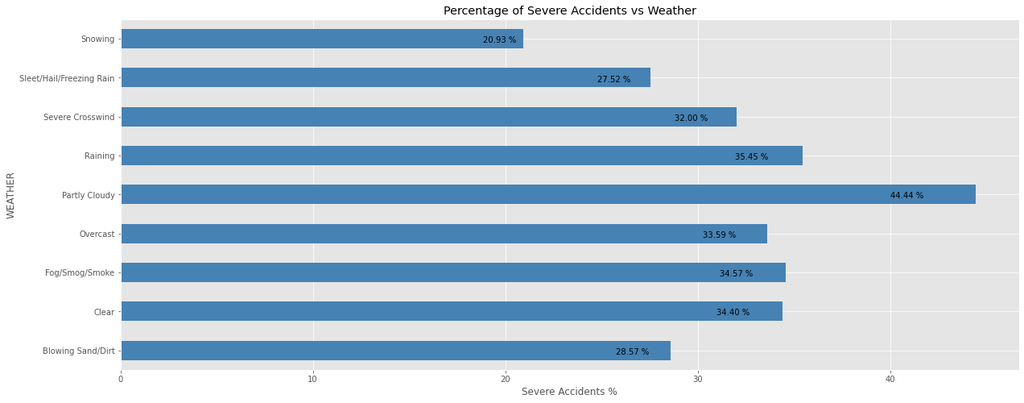

```python
plot_weather.plot(kind='barh', figsize=(20,8),color='steelblue')
plt.xlabel('Severe Accidents %')
plt.title('Percentage of Severe Accidents vs Weather')
for index, value in enumerate(plot_weather):
    label = "%.2f" % ((value)) + r' %' # format int with commas

    # place text at the end of bar (subtracting 47000 from x, and 0.1 from y to make it fit within the bar)
    plt.annotate(label, xy=(0.9*value , index - 0.10), color='black')
plt.show()
```

```python
# severity of accidents vs weekday
df3.head()
df_wkd_scode=df3[['DAYOFWEEK','SEVERITYCODE']]
df_wkd_scode['Total'] = df_wkd_scode.sum(axis=1)
data_to_plot_wkd = df_wkd_scode.groupby(['DAYOFWEEK','SEVERITYCODE'], as_index=False).count()
data_to_plot_wkd_1=data_to_plot_wkd[data_to_plot_wkd['SEVERITYCODE']=='1']
data_to_plot_wkd_2=data_to_plot_wkd[data_to_plot_wkd['SEVERITYCODE']=='2']
data_to_plot_wkd_1.rename(columns={'SERITYCODE':'Incident_1', 'Total':'Total_INC1'},inplace=True)
data_to_plot_wkd_2.rename(columns={'SERITYCODE':'Incident_2', 'Total':'Total_INC2'},inplace=True)
data_to_plot_wkd_1.set_index('DAYOFWEEK', inplace=True)
data_to_plot_wkd_2.set_index('DAYOFWEEK', inplace=True)

plot_wkd  = pd.concat([data_to_plot_wkd_1, data_to_plot_wkd_2], axis=1, join='inner')
```

```python
plot_wkd_bar=plot_wkd[['Total_INC1','Total_INC2']]
```

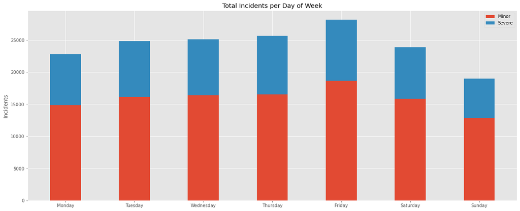

```python
ind = np.arange(7)
width = 0.45
plt.figure(figsize=(20,8))
p1 = plt.bar(ind, plot_wkd_bar["Total_INC1"], width)
p2 = plt.bar(ind, plot_wkd_bar["Total_INC2"], width, bottom=plot_wkd_bar["Total_INC1"])

plt.ylabel("Incidents")
plt.title("Total Incidents per Day of Week")
plt.xticks(ind, ("Monday", "Tuesday", "Wednesday", "Thursday", "Friday", "Saturday", "Sunday"))
plt.legend((p1[0], p2[0]), ('Minor', 'Severe'))
plt.show()
```

```python
df3.groupby(['DAYOFWEEK'])['SEVERITYCODE'].value_counts(normalize=True)*100
```

```
DAYOFWEEK  SEVERITYCODE
0          1               64.943613
           2               35.056387
1          1               65.034627
           2               34.965373
2          1               65.196449
           2               34.803551
3          1               64.482920
           2               35.517080
4          1               66.033052
           2               33.966948
5          1               66.287388
           2               33.712612
6          1               67.672459
           2               32.327541
Name: SEVERITYCODE, dtype: float64
```

The day of week may influence the outcome of the accident, but it does not: for every day, the ratio is similar to that of the total data set

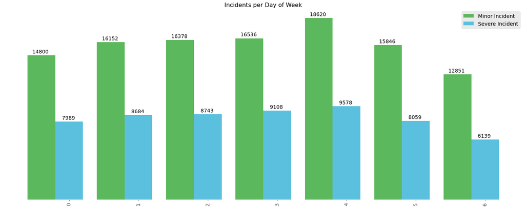

```python
#look on the total incident per week day
fig, ax = plt.subplots(figsize=(20,8))
ax.set_facecolor((1,1,1))
labels = plot_wkd_bar.index
xs = np.arange(len(labels))*2
width = 0.8
rectss = [ax.bar(xs - width, plot_wkd_bar["Total_INC1"], width, label="Minor Incident", color="#5cb85c"),
          ax.bar(xs, plot_wkd_bar["Total_INC2"], width, label="Severe Incident", color="#5bc0de")

         ]
ax.axes.get_yaxis().set_visible(False)
ax.set_xticks(xs)
ax.set_xticklabels(labels, fontsize=14, rotation=90)
ax.legend(fontsize=14)
ax.set_title('Incidents per Day of Week', fontsize=16)
for rects in rectss:
    for rect in rects:
        height = rect.get_height()
        ax.annotate('{} '.format(height),
                    xy=(rect.get_x() + rect.get_width() / 2, height),
                    xytext=(0, 3),  # 3 points vertical offset
                    textcoords="offset points",
                    ha='center', va='bottom',
                    fontsize=14)
fig.tight_layout()
plt.show()
```

```python
# severity vs Month
df3.head()
df_month_scode=df3[['MONTH','SEVERITYCODE']]
df_month_scode['Total'] = df_month_scode.sum(axis=1)
data_to_plot_month = df_month_scode.groupby(['MONTH','SEVERITYCODE'], as_index=False).count()
data_to_plot_month_1=data_to_plot_month[data_to_plot_month['SEVERITYCODE']=='1']
data_to_plot_month_2=data_to_plot_month[data_to_plot_month['SEVERITYCODE']=='2']
data_to_plot_month_1.rename(columns={'SERITYCODE':'Incident_1', 'Total':'Total_INC1'},inplace=True)
data_to_plot_month_2.rename(columns={'SERITYCODE':'Incident_2', 'Total':'Total_INC2'},inplace=True)
data_to_plot_month_1.set_index('MONTH', inplace=True)
data_to_plot_month_2.set_index('MONTH', inplace=True)

plot_month  = pd.concat([data_to_plot_month_1, data_to_plot_month_2], axis=1, join='inner')
plot_month_bar=plot_month[['Total_INC1','Total_INC2']]
```

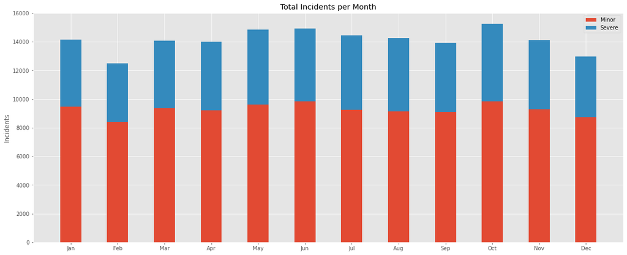

```python
ind = np.arange(12)
width = 0.45
plt.figure(figsize=(20,8))
p1 = plt.bar(ind, plot_month_bar["Total_INC1"], width)
p2 = plt.bar(ind, plot_month_bar["Total_INC2"], width, bottom=plot_month_bar["Total_INC1"])

plt.ylabel("Incidents")
plt.title("Total Incidents per Month")
plt.xticks(ind, ("Jan", "Feb", "Mar", "Apr", "May", "Jun", "Jul","Aug","Sep","Oct","Nov","Dec"))
plt.legend((p1[0], p2[0]), ('Minor', 'Severe'))
plt.show()
```

```python
df3.groupby(['MONTH'])['SEVERITYCODE'].value_counts(normalize=True)*100
```

```
MONTH  SEVERITYCODE
1      1               66.932580
       2               33.067420
2      1               67.366565
       2               32.633435
3      1               66.333049
       2               33.666951
4      1               65.925661
       2               34.074339
5      1               64.726489
       2               35.273511
6      1               66.016358
       2               33.983642
7      1               63.894846
       2               36.105154
8      1               63.937758
       2               36.062242
9      1               65.242983
       2               34.757017
10     1               64.377373
       2               35.622627
11     1               65.730496
       2               34.269504
12     1               67.244701
       2               32.755299
Name: SEVERITYCODE, dtype: float64
```

The ratio of minor to severe accidents per month represents roughly the distribution in the whole data set. Therefore, the month was ultimately not included in the modeling features.

```python
# severity vs Juctiontype

df_jct_scode=df3[['JUNCTIONTYPE','SEVERITYCODE']]
df_jct_scode['Total'] = df_jct_scode.sum(axis=1)
data_to_plot_jct = df_jct_scode.groupby(['JUNCTIONTYPE','SEVERITYCODE'], as_index=False).count()
data_to_plot_jct_1=data_to_plot_jct[data_to_plot_jct['SEVERITYCODE']=='1']
data_to_plot_jct_2=data_to_plot_jct[data_to_plot_jct['SEVERITYCODE']=='2']
data_to_plot_jct_1.rename(columns={'SEVERITYCODE':'Incident_1', 'Total':'Total_INC1'},inplace=True)
data_to_plot_jct_2.rename(columns={'SEVERITYCODE':'Incident_2', 'Total':'Total_INC2'},inplace=True)
data_to_plot_jct_1.set_index('JUNCTIONTYPE', inplace=True)
data_to_plot_jct_2.set_index('JUNCTIONTYPE', inplace=True)

plot_jct  = pd.concat([data_to_plot_jct_1, data_to_plot_jct_2], axis=1, join='inner')
plot_jct_bar=plot_jct[['Total_INC1','Total_INC2']]

plot_jct_bar['Total_Jct']=plot_jct_bar[['Total_INC1','Total_INC2']].sum(axis=1)
plot_jct_bar['Per_Inc2']=plot_jct_bar['Total_INC2']/plot_jct_bar['Total_Jct']
plot_jct_bar1=plot_jct_bar['Per_Inc2']*100
plot_jct_bar1
```

```
JUNCTIONTYPE
At Intersection (but not related to intersection)    34.388889
At Intersection (intersection related)               45.632732
Driveway Junction                                    32.485848
Mid-Block (but intersection related)                 33.583960
Mid-Block (not related to intersection)              25.712801
Ramp Junction                                        35.036496
Name: Per_Inc2, dtype: float64
```

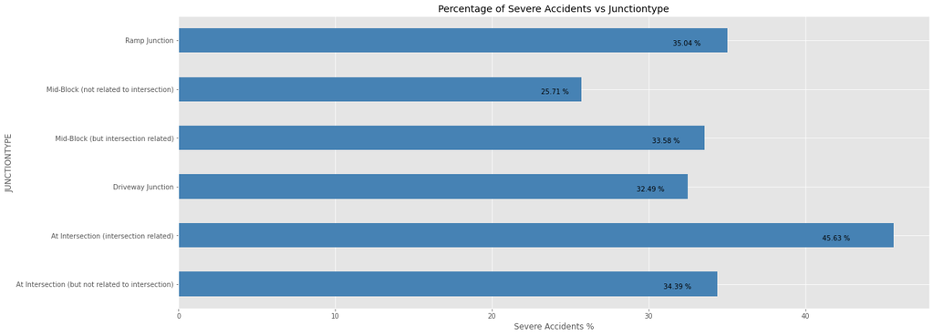

```python
plot_jct_bar1.plot(kind='barh', figsize=(20,8),color='steelblue')
plt.xlabel('Severe Accidents %')
plt.title('Percentage of Severe Accidents vs Junctiontype')
for index, value in enumerate(plot_jct_bar1):
    label = "%.2f" % ((value)) + r' %' # format int with commas

    # place text at the end of bar (subtracting 47000 from x, and 0.1 from y to make it fit within the bar)
    plt.annotate(label, xy=(0.9*value , index - 0.10), color='black')
plt.show()
```

```python
# severity vs Light Condition

df_lc_scode=df3[['LIGHTCOND','SEVERITYCODE']]
df_lc_scode['Total'] = df_lc_scode.sum(axis=1)
data_to_plot_lc = df_lc_scode.groupby(['LIGHTCOND','SEVERITYCODE'], as_index=False).count()
data_to_plot_lc_1=data_to_plot_lc[data_to_plot_lc['SEVERITYCODE']=='1']
data_to_plot_lc_2=data_to_plot_lc[data_to_plot_lc['SEVERITYCODE']=='2']
data_to_plot_lc_1.rename(columns={'SEVERITYCODE':'Incident_1', 'Total':'Total_INC1'},inplace=True)
data_to_plot_lc_2.rename(columns={'SEVERITYCODE':'Incident_2', 'Total':'Total_INC2'},inplace=True)
data_to_plot_lc_1.set_index('LIGHTCOND', inplace=True)
data_to_plot_lc_2.set_index('LIGHTCOND', inplace=True)

plot_lc  = pd.concat([data_to_plot_lc_1, data_to_plot_lc_2], axis=1, join='inner')
plot_lc_bar=plot_lc[['Total_INC1','Total_INC2']]

plot_lc_bar['Total_LC']=plot_lc_bar[['Total_INC1','Total_INC2']].sum(axis=1)
plot_lc_bar['Per_Inc2']=plot_lc_bar['Total_INC2']/plot_lc_bar['Total_LC']
plot_lc_bar1=plot_lc_bar['Per_Inc2']*100
plot_lc_bar1
```

```
LIGHTCOND
Dark - No Street Lights     24.962853
Dark - Street Lights Off    29.954338
Dark - Street Lights On     32.525885
Dark - Unknown Lighting     40.000000
Dawn                        35.886761
Daylight                    35.253477
Dusk                        35.330505
Name: Per_Inc2, dtype: float64
```

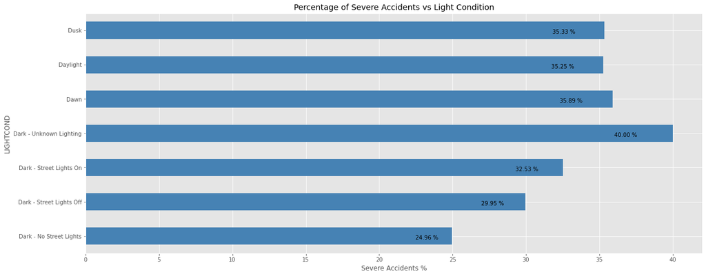

```python
plot_lc_bar1.plot(kind='barh', figsize=(20,8),color='steelblue')
plt.xlabel('Severe Accidents %')
plt.title('Percentage of Severe Accidents vs Light Condition')
for index, value in enumerate(plot_lc_bar1):
    label = "%.2f" % ((value)) + r' %' # format int with commas

    # place text at the end of bar (subtracting 47000 from x, and 0.1 from y to make it fit within the bar)
    plt.annotate(label, xy=(0.9*value , index - 0.10), color='black')
plt.show()
```

```python
# Serveritycode vs Waethercond

df_weathercond=df3[['WEATHER','SEVERITYCODE']]
df_weathercond['Total'] = df_weathercond.sum(axis=1)
data_to_plot_wea = df_weathercond.groupby(['WEATHER','SEVERITYCODE'], as_index=False).count()
data_to_plot_wea_1=data_to_plot_wea[data_to_plot_wea['SEVERITYCODE']=='1']
data_to_plot_wea_2=data_to_plot_wea[data_to_plot_wea['SEVERITYCODE']=='2']
data_to_plot_wea_1.rename(columns={'SERITYCODE':'Incident_1', 'Total':'Total_INC1'},inplace=True)
data_to_plot_wea_2.rename(columns={'SERITYCODE':'Incident_2', 'Total':'Total_INC2'},inplace=True)
data_to_plot_wea_1.set_index('WEATHER', inplace=True)
data_to_plot_wea_2.set_index('WEATHER', inplace=True)

plot_wea  = pd.concat([data_to_plot_wea_1, data_to_plot_wea_2], axis=1, join='inner')
```

```python
plot_wea['Total_Weather']=plot_wea[['Total_INC1','Total_INC2']].sum(axis=1)
plot_wea['Per_Inc2']=plot_wea['Total_INC2']/plot_wea['Total_Weather']
plot_weather=plot_wea['Per_Inc2']*100
plot_weather
```

```
WEATHER
Blowing Sand/Dirt           28.571429
Clear                       34.396671
Fog/Smog/Smoke              34.565619
Overcast                    33.589801
Partly Cloudy               44.444444
Raining                     35.451578
Severe Crosswind            32.000000
Sleet/Hail/Freezing Rain    27.522936
Snowing                     20.930233
Name: Per_Inc2, dtype: float64
```

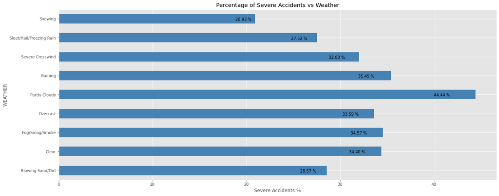

```python
plot_weather.plot(kind='barh', figsize=(20,8),color='steelblue')
plt.xlabel('Severe Accidents %')
plt.title('Percentage of Severe Accidents vs Weather')
for index, value in enumerate(plot_weather):
    label = "%.2f" % ((value)) + r' %' # format int with commas

    # place text at the end of bar (subtracting 47000 from x, and 0.1 from y to make it fit within the bar)
    plt.annotate(label, xy=(0.9*value , index - 0.10), color='black')
plt.show()
```

```python
# look on locations starting june 2020 to 29th of july 2020
df_year = df3[df3.INCDATE >= '2020-06-01']
df_year.shape
```

```
(436, 15)
```

```python
import folium
# create map and display it
latitude=47.608
longitude=-122.3351

from folium import plugins

# let's start again with a clean copy of the map of San Francisco
seattle_map = folium.Map(location = [latitude, longitude], zoom_start = 11)

# instantiate a mark cluster object for the incidents in the dataframe
incidents = plugins.MarkerCluster().add_to(seattle_map)

# loop through the dataframe and add each data point to the mark cluster
for lat, lng, label, in zip(df_year.Y, df_year.X, df_year.SEVERITYCODE):
    folium.Marker(
        location=[lat, lng],
        icon=None,
        popup=label,
    ).add_to(incidents)

# display map
seattle_map
```

Make this Notebook Trusted to load map: File -> Trust Notebook

[interactive chart not shown]

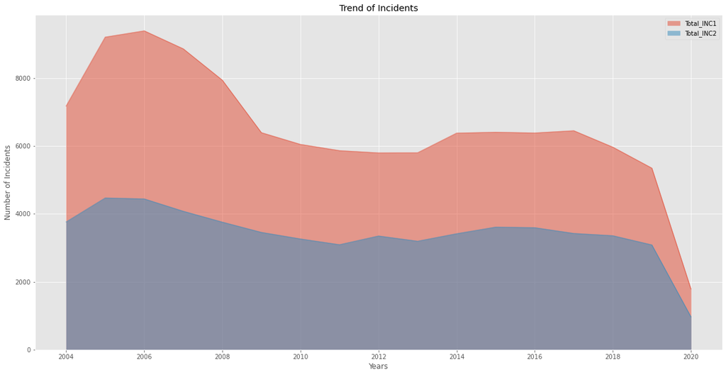

```python
# trend per year

df_year_scode=df3[['YEAR','SEVERITYCODE']]
df_year_scode['Total'] = df_year_scode.sum(axis=1)
data_plot_year = df_year_scode.groupby(['YEAR','SEVERITYCODE'], as_index=False).count()
data_plot_year_1=data_plot_year[data_plot_year['SEVERITYCODE']=='1']
data_plot_year_2=data_plot_year[data_plot_year['SEVERITYCODE']=='2']

data_plot_year_1.set_index('YEAR', inplace=True)
data_plot_year_2.set_index('YEAR', inplace=True)
data_plot_year_1.rename(columns={'Total':'Total_INC1'},inplace=True)
data_plot_year_2.rename(columns={'Total':'Total_INC2'},inplace=True)
plot_area_year  = pd.concat([data_plot_year_1, data_plot_year_2], axis=1, join='inner')
plot_area=plot_area_year[['Total_INC1','Total_INC2']]
plot_area.plot(kind='area',
             stacked=False,
             figsize=(20, 10), # pass a tuple (x, y) size
             )

plt.title('Trend of Incidents')
plt.ylabel('Number of Incidents')
plt.xlabel('Years')

plt.show()
```

```python
#influence of speeding
df3.groupby(['SPEEDING'])['SEVERITYCODE'].value_counts(normalize=True)*100
```

```
SPEEDING  SEVERITYCODE
0.0       1               65.996860
          2               34.003140
1.0       1               58.538213
          2               41.461787
Name: SEVERITYCODE, dtype: float64
```

```python
# serverity vs PERSONCount
#new_df[new_df['2000s']> 209611.5]
df_pc_scode_1=df3[df3['PERSONCOUNT']<100]
df_pc_scode=df_pc_scode_1[['PERSONCOUNT','SEVERITYCODE']]
df_pc_scode['Total'] = df_pc_scode.sum(axis=1)
data_to_plot_pc = df_pc_scode.groupby(['PERSONCOUNT','SEVERITYCODE'], as_index=False).count()
data_to_plot_pc
data_to_plot_pc_1=data_to_plot_pc[data_to_plot_pc['SEVERITYCODE']=='1']
data_to_plot_pc_2=data_to_plot_pc[data_to_plot_pc['SEVERITYCODE']=='2']
data_to_plot_pc_1.rename(columns={'SEVERITYCODE':'Incident_1', 'Total':'Total_INC1'},inplace=True)
data_to_plot_pc_2.rename(columns={'SEVERITYCODE':'Incident_2', 'Total':'Total_INC2'},inplace=True)
data_to_plot_pc_1.set_index('PERSONCOUNT', inplace=True)
data_to_plot_pc_2.set_index('PERSONCOUNT', inplace=True)

plot_pc  = pd.concat([data_to_plot_pc_1, data_to_plot_pc_2], axis=1, join='outer')
plot_pc_bar=plot_pc[['Total_INC1','Total_INC2']]

plot_pc_bar['Total_PC']=plot_pc_bar[['Total_INC1','Total_INC2']].sum(axis=1)
plot_pc_bar.replace(np.nan, 0, inplace=True)
plot_pc_bar['Per_Inc2']=plot_pc_bar['Total_INC2']/plot_pc_bar['Total_PC']*100
plot_pc_bar['Per_Inc1']=plot_pc_bar['Total_INC1']/plot_pc_bar['Total_PC']*100

#plot_pc_bar1=plot_pc_bar['Per_Inc2']/100
#plot_pc_bar1
```

```python
plot_pc_bar.sort_values(['Total_PC'], ascending=False, axis=0, inplace=True)
plot_pc_top15=plot_pc_bar.head(15)
plot_pc_top15_bar=plot_pc_top15['Per_Inc2']
plot_pc_top15
```

| PERSONCOUNT | Total_INC1 | Total_INC2 | Total_PC | Per_Inc2 | Per_Inc1 |
| --- | --- | --- | --- | --- | --- |
| 2 | 65934.0 | 27884.0 | 93818.0 | 29.721375 | 70.278625 |
| 3 | 20697.0 | 13612.0 | 34309.0 | 39.674721 | 60.325279 |
| 4 | 7936.0 | 6323.0 | 14259.0 | 44.343923 | 55.656077 |
| 1 | 7438.0 | 3059.0 | 10497.0 | 29.141660 | 70.858340 |
| 5 | 3498.0 | 3030.0 | 6528.0 | 46.415441 | 53.584559 |
| 0 | 3406.0 | 1724.0 | 5130.0 | 33.606238 | 66.393762 |
| 6 | 1310.0 | 1389.0 | 2699.0 | 51.463505 | 48.536495 |
| 7 | 469.0 | 662.0 | 1131.0 | 58.532272 | 41.467728 |
| 8 | 240.0 | 287.0 | 527.0 | 54.459203 | 45.540797 |
| 9 | 81.0 | 132.0 | 213.0 | 61.971831 | 38.028169 |
| 10 | 55.0 | 76.0 | 131.0 | 58.015267 | 41.984733 |
| 11 | 21.0 | 35.0 | 56.0 | 62.500000 | 37.500000 |
| 12 | 13.0 | 21.0 | 34.0 | 61.764706 | 38.235294 |
| 13 | 8.0 | 13.0 | 21.0 | 61.904762 | 38.095238 |
| 14 | 11.0 | 9.0 | 20.0 | 45.000000 | 55.000000 |

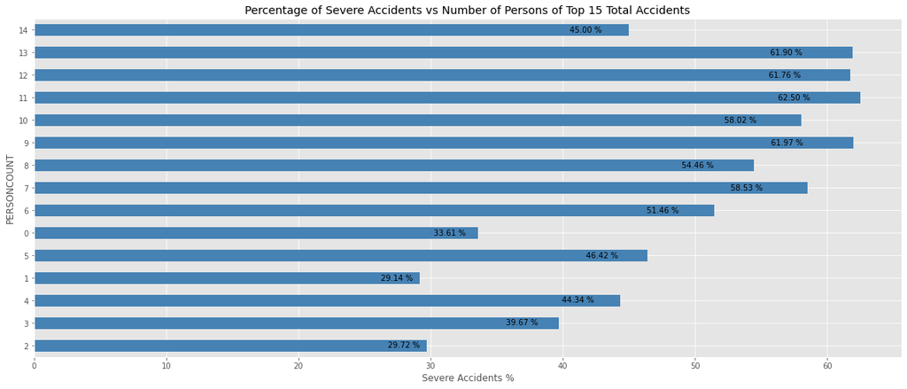

```python
plot_pc_top15_bar.plot(kind='barh', figsize=(20,8),color='steelblue')
plt.xlabel('Severe Accidents %')
plt.title('Percentage of Severe Accidents vs Number of Persons of Top 15 Total Accidents')
for index, value in enumerate(plot_pc_top15_bar):
    label = "%.2f" % ((value)) + r' %' # format int with commas

    # place text at the end of bar (subtracting 47000 from x, and 0.1 from y to make it fit within the bar)
    plt.annotate(label, xy=(0.9*value , index - 0.10), color='black')
plt.show()
```

```python
# influence of involved vehicles
df3.groupby(['VEHCOUNT'])['SEVERITYCODE'].value_counts(normalize=True)*100
```

```
VEHCOUNT  SEVERITYCODE
0         2                98.666667
          1                 1.333333
1         2                59.935617
          1                40.064383
2         1                71.969738
          2                28.030262
3         1                56.131288
          2                43.868712
4         1                53.294412
          2                46.705588
5         2                50.654206
          1                49.345794
6         1                56.462585
          2                43.537415
7         2                53.191489
          1                46.808511
8         1                61.111111
          2                38.888889
9         2                70.000000
          1                30.000000
10        2               100.000000
11        1                60.000000
          2                40.000000
12        1               100.000000
13        2               100.000000
14        2               100.000000
15        2               100.000000
Name: SEVERITYCODE, dtype: float64
```

```python
# serverity vs VEHCOUNT

df_vc_scode=df3[['VEHCOUNT','SEVERITYCODE']]
df_vc_scode['Total'] = df_vc_scode.sum(axis=1)
#
data_to_plot_vc = df_vc_scode.groupby(['VEHCOUNT','SEVERITYCODE'], as_index=False).count()
data_to_plot_vc
#data_to_plot_vc
data_to_plot_vc_1=data_to_plot_vc[data_to_plot_vc['SEVERITYCODE']=='1']
data_to_plot_vc_2=data_to_plot_vc[data_to_plot_vc['SEVERITYCODE']=='2']
data_to_plot_vc_1.rename(columns={'SEVERITYCODE':'Incident_1', 'Total':'Total_INC1'},inplace=True)
data_to_plot_vc_2.rename(columns={'SEVERITYCODE':'Incident_2', 'Total':'Total_INC2'},inplace=True)
data_to_plot_vc_1.set_index('VEHCOUNT', inplace=True)
data_to_plot_vc_2.set_index('VEHCOUNT', inplace=True)

plot_vc  = pd.concat([data_to_plot_vc_1, data_to_plot_vc_2], axis=1, join='outer')
plot_vc_bar=plot_vc[['Total_INC1','Total_INC2']]


plot_vc_bar.replace(np.nan, 0, inplace=True)

plot_vc_bar_total=plot_vc_bar
plot_vc_bar_total
plot_vc_bar_total['Total_VC']=plot_vc_bar_total[['Total_INC1','Total_INC2']].sum(axis=1)
plot_vc_bar_total['Per_Inc2']=plot_vc_bar_total['Total_INC2']/plot_vc_bar_total['Total_VC']*100
plot_vc_bar_total['Per_Inc1']=plot_vc_bar_total['Total_INC1']/plot_vc_bar_total['Total_VC']*100
plot_vc_bar_total
#plot_vc_bar_total1=plot_vc_bar_total['Per_Inc1','Per_Inc2']
```

| VEHCOUNT | Total_INC1 | Total_INC2 | Total_VC | Per_Inc2 | Per_Inc1 |
| --- | --- | --- | --- | --- | --- |
| 0 | 3.0 | 222.0 | 225.0 | 98.666667 | 1.333333 |
| 1 | 10081.0 | 15081.0 | 25162.0 | 59.935617 | 40.064383 |
| 2 | 92371.0 | 35976.0 | 128347.0 | 28.030262 | 71.969738 |
| 3 | 7063.0 | 5520.0 | 12583.0 | 43.868712 | 56.131288 |
| 4 | 1278.0 | 1120.0 | 2398.0 | 46.705588 | 53.294412 |
| 5 | 264.0 | 271.0 | 535.0 | 50.654206 | 49.345794 |
| 6 | 83.0 | 64.0 | 147.0 | 43.537415 | 56.462585 |
| 7 | 22.0 | 25.0 | 47.0 | 53.191489 | 46.808511 |
| 8 | 11.0 | 7.0 | 18.0 | 38.888889 | 61.111111 |
| 9 | 3.0 | 7.0 | 10.0 | 70.000000 | 30.000000 |
| 10 | 0.0 | 2.0 | 2.0 | 100.000000 | 0.000000 |
| 11 | 3.0 | 2.0 | 5.0 | 40.000000 | 60.000000 |
| 12 | 1.0 | 0.0 | 1.0 | 0.000000 | 100.000000 |
| 13 | 0.0 | 1.0 | 1.0 | 100.000000 | 0.000000 |
| 14 | 0.0 | 1.0 | 1.0 | 100.000000 | 0.000000 |
| 15 | 0.0 | 1.0 | 1.0 | 100.000000 | 0.000000 |

```python
plot_veh=plot_vc_bar_total.head(7)
```

```python
# show only first 7 of 15 vehicle counts
plot_veh
```

| VEHCOUNT | Total_INC1 | Total_INC2 | Total_VC | Per_Inc2 | Per_Inc1 |
| --- | --- | --- | --- | --- | --- |
| 0 | 3.0 | 222.0 | 225.0 | 98.666667 | 1.333333 |
| 1 | 10081.0 | 15081.0 | 25162.0 | 59.935617 | 40.064383 |
| 2 | 92371.0 | 35976.0 | 128347.0 | 28.030262 | 71.969738 |
| 3 | 7063.0 | 5520.0 | 12583.0 | 43.868712 | 56.131288 |
| 4 | 1278.0 | 1120.0 | 2398.0 | 46.705588 | 53.294412 |
| 5 | 264.0 | 271.0 | 535.0 | 50.654206 | 49.345794 |
| 6 | 83.0 | 64.0 | 147.0 | 43.537415 | 56.462585 |

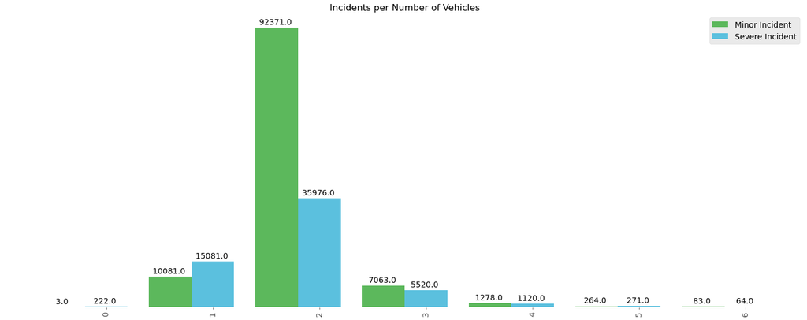

```python
fig, ax = plt.subplots(figsize=(20,8))
ax.set_facecolor((1,1,1))
labels = plot_veh.index
xs = np.arange(len(labels))*2
width = 0.8
rectss = [ax.bar(xs - width, plot_veh["Total_INC1"], width, label="Minor Incident", color="#5cb85c"),
          ax.bar(xs, plot_veh["Total_INC2"], width, label="Severe Incident", color="#5bc0de")

         ]
ax.axes.get_yaxis().set_visible(False)
ax.set_xticks(xs)
ax.set_xticklabels(labels, fontsize=14, rotation=90)
ax.legend(fontsize=14)
ax.set_title('Incidents per Number of Vehicles', fontsize=16)
for rects in rectss:
    for rect in rects:
        height = rect.get_height()
        ax.annotate('{} '.format(height),
                    xy=(rect.get_x() + rect.get_width() / 2, height),
                    xytext=(0, 3),  # 3 points vertical offset
                    textcoords="offset points",
                    ha='center', va='bottom',
                    fontsize=14)
fig.tight_layout()
plt.show()
```

```python
plot_vc_bar.head(7)
```

| VEHCOUNT | Total_INC1 | Total_INC2 | Total_VC | Per_Inc2 | Per_Inc1 |
| --- | --- | --- | --- | --- | --- |
| 0 | 3.0 | 222.0 | 225.0 | 98.666667 | 1.333333 |
| 1 | 10081.0 | 15081.0 | 25162.0 | 59.935617 | 40.064383 |
| 2 | 92371.0 | 35976.0 | 128347.0 | 28.030262 | 71.969738 |
| 3 | 7063.0 | 5520.0 | 12583.0 | 43.868712 | 56.131288 |
| 4 | 1278.0 | 1120.0 | 2398.0 | 46.705588 | 53.294412 |
| 5 | 264.0 | 271.0 | 535.0 | 50.654206 | 49.345794 |
| 6 | 83.0 | 64.0 | 147.0 | 43.537415 | 56.462585 |

```python
plot_vc2=plot_vc_bar.head(7)
```

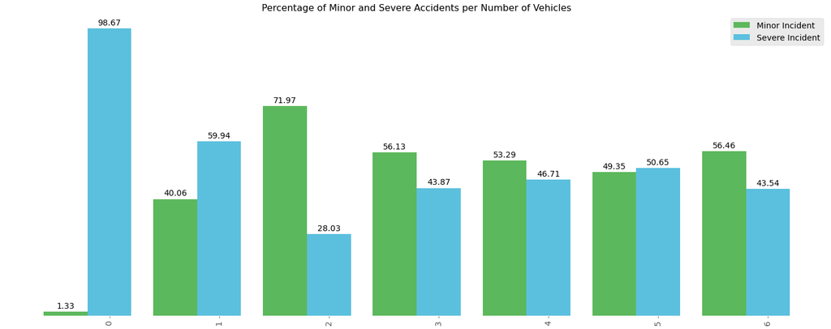

```python
fig, ax = plt.subplots(figsize=(20,8))
ax.set_facecolor((1,1,1))
labels = plot_vc2.index
xs = np.arange(len(labels))*2
width = 0.8
rectss = [ax.bar(xs - width, plot_vc2["Per_Inc1"], width, label="Minor Incident", color="#5cb85c"),
          ax.bar(xs, plot_vc2["Per_Inc2"], width, label="Severe Incident", color="#5bc0de")

         ]
ax.axes.get_yaxis().set_visible(False)
ax.set_xticks(xs)
ax.set_xticklabels(labels, fontsize=14, rotation=90)
ax.legend(fontsize=14)
ax.set_title('Percentage of Minor and Severe Accidents per Number of Vehicles', fontsize=16)
for rects in rectss:
    for rect in rects:
        height = rect.get_height()
        ax.annotate('%.2f' % (height),
                    xy=(rect.get_x() + rect.get_width() / 2, height),
                    xytext=(0, 3),  # 3 points vertical offset
                    textcoords="offset points",
                    ha='center', va='bottom',
                    fontsize=14)
fig.tight_layout()
plt.show()
```

### Features

```python
results = df3['SEVERITYCODE']
values = df3[['X', 'Y', 'SPEEDING', 'PERSONCOUNT','VEHCOUNT']]
values = pd.concat([values, pd.get_dummies(df3['WEATHER']), pd.get_dummies(df3['LIGHTCOND']), pd.get_dummies(df3['ROADCOND']), pd.get_dummies(df3['JUNCTIONTYPE'])], axis=1)
```

```python
values
```

|  | X | Y | SPEEDING | PERSONCOUNT | VEHCOUNT | Blowing Sand/Dirt | Clear | Fog/Smog/Smoke | Overcast | Partly Cloudy | ... | Sand/Mud/Dirt | Snow/Slush | Standing Water | Wet | At Intersection (but not related to intersection) | At Intersection (intersection related) | Driveway Junction | Mid-Block (but intersection related) | Mid-Block (not related to intersection) | Ramp Junction |
| --- | --- | --- | --- | --- | --- | --- | --- | --- | --- | --- | --- | --- | --- | --- | --- | --- | --- | --- | --- | --- | --- |
| 0 | -122.386772 | 47.564720 | 0.0 | 2 | 1 | 0 | 1 | 0 | 0 | 0 | ... | 0 | 0 | 0 | 0 | 0 | 1 | 0 | 0 | 0 | 0 |
| 1 | -122.341806 | 47.686934 | 0.0 | 4 | 2 | 0 | 0 | 0 | 0 | 0 | ... | 0 | 0 | 0 | 1 | 0 | 1 | 0 | 0 | 0 | 0 |
| 2 | -122.374899 | 47.668666 | 0.0 | 4 | 3 | 0 | 1 | 0 | 0 | 0 | ... | 0 | 0 | 0 | 0 | 0 | 0 | 0 | 0 | 1 | 0 |
| 3 | -122.300758 | 47.683047 | 0.0 | 2 | 2 | 0 | 0 | 0 | 0 | 0 | ... | 0 | 0 | 0 | 1 | 0 | 1 | 0 | 0 | 0 | 0 |
| 4 | -122.323569 | 47.722577 | 0.0 | 2 | 2 | 0 | 1 | 0 | 0 | 0 | ... | 0 | 0 | 0 | 0 | 0 | 0 | 0 | 0 | 1 | 0 |
| ... | ... | ... | ... | ... | ... | ... | ... | ... | ... | ... | ... | ... | ... | ... | ... | ... | ... | ... | ... | ... | ... |
| 169478 | -122.335908 | 47.598750 | 0.0 | 2 | 2 | 0 | 0 | 0 | 1 | 0 | ... | 0 | 0 | 0 | 0 | 0 | 0 | 0 | 1 | 0 | 0 |
| 169479 | -122.314961 | 47.523468 | 0.0 | 2 | 2 | 0 | 1 | 0 | 0 | 0 | ... | 0 | 0 | 0 | 0 | 0 | 0 | 0 | 0 | 1 | 0 |
| 169480 | -122.334203 | 47.575576 | 0.0 | 2 | 2 | 0 | 1 | 0 | 0 | 0 | ... | 0 | 0 | 0 | 0 | 0 | 1 | 0 | 0 | 0 | 0 |
| 169481 | -122.310259 | 47.594214 | 0.0 | 3 | 2 | 0 | 1 | 0 | 0 | 0 | ... | 0 | 0 | 0 | 0 | 0 | 0 | 1 | 0 | 0 | 0 |
| 169482 | -122.342627 | 47.651619 | 0.0 | 4 | 3 | 0 | 1 | 0 | 0 | 0 | ... | 0 | 0 | 0 | 0 | 0 | 0 | 0 | 0 | 1 | 0 |

169483 rows × 34 columns

## Predictive Modeling

```python
# import decision trees scikit-learn libraries
%matplotlib inline
from sklearn import tree
from sklearn.metrics import accuracy_score, confusion_matrix

import matplotlib.pyplot as plt

#!conda install python-graphviz --yes
import graphviz

from sklearn.tree import export_graphviz

import itertools
```

```python
# create train and test set
from sklearn.model_selection import train_test_split
X_train, X_test, y_train, y_test = train_test_split(values, results, test_size=0.2, random_state=4)
print ('Train set:', X_train.shape,  y_train.shape)
print ('Test set:', X_test.shape,  y_test.shape)
```

```
Train set: (135586, 34) (135586,)
Test set: (33897, 34) (33897,)
```

```python
from sklearn.tree import DecisionTreeClassifier
# decission tree
Ks = 30
mean_acc = np.zeros((Ks-1))
std_acc = np.zeros((Ks-1))
ConfustionMx = []
for n in range(1,Ks):
    print(n, end=' ')
    #Train Model and Predict
    ltree = DecisionTreeClassifier(criterion="entropy", max_depth = n).fit(X_train,y_train)
    yhat=ltree.predict(X_test)
    mean_acc[n-1] = accuracy_score(y_test, yhat)


    std_acc[n-1]=np.std(yhat==y_test)/np.sqrt(yhat.shape[0])

mean_acc
```

```
1 2 3 4 5 6 7 8 9 10 11 12 13 14 15 16 17 18 19 20 21 22 23 24 25 26 27 28 29
```

```
array([0.68551789, 0.71292445, 0.71386848, 0.71625808, 0.71909018,
       0.72027023, 0.72106676, 0.72142077, 0.72029973, 0.71888368,
       0.71805765, 0.71655309, 0.71534354, 0.71268844, 0.70846978,
       0.70593268, 0.70428061, 0.69994395, 0.69843939, 0.69433873,
       0.68964805, 0.68649143, 0.68413134, 0.67873263, 0.67705107,
       0.67348143, 0.67059032, 0.66631265, 0.66424757])
```

```
The best accuracy was with 0.7214207746998259 with k = 8
```

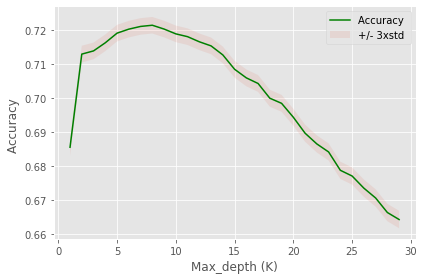

```python
plt.plot(range(1,Ks),mean_acc,'g')
plt.fill_between(range(1,Ks),mean_acc - 1 * std_acc,mean_acc + 1 * std_acc, alpha=0.10)
plt.legend(('Accuracy ', '+/- 3xstd'))
plt.ylabel('Accuracy ')
plt.xlabel('Max_depth (K)')
plt.tight_layout()
tree_best_k = mean_acc.argmax()+1
print("The best accuracy was with", mean_acc.max(), "with k =", tree_best_k)
plt.show()
```

```python
decision_tree = DecisionTreeClassifier(criterion='entropy', max_depth=tree_best_k).fit(X_train, y_train)
```

```
dot: graph is too large for cairo-renderer bitmaps. Scaling by 0.830827 to fit
```

[figure not shown]

```python
from six import StringIO
import pydotplus, graphviz
import matplotlib.image as mpimg
dot_data = StringIO()
filename = "Cap_2_tree.png"
feature_names = X_train.columns
target_names = df3['SEVERITYCODE'].unique().tolist()
out = tree.export_graphviz(decision_tree, feature_names=feature_names, out_file=dot_data, class_names=target_names, filled=True,  special_characters=True,rotate=False)
graph = pydotplus.graph_from_dot_data(dot_data.getvalue())
graph.write_png(filename)
img = mpimg.imread(filename)
plt.figure(figsize=(100, 200))
plt.imshow(img,interpolation='nearest')
```

```python
tree_yhat = decision_tree.predict(X_test)
```

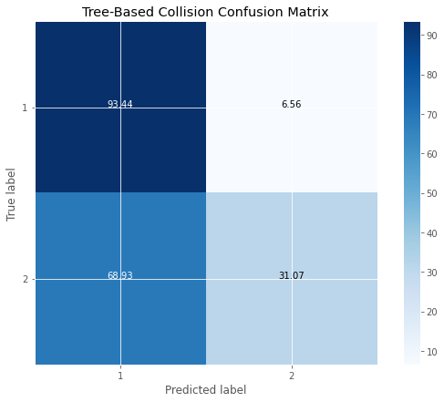

```python
import itertools
test_results = np.unique(y_test)
tree_confusion_matrix = confusion_matrix(y_test, tree_yhat, test_results)
title = 'Tree-Based Collision Confusion Matrix'
cmap = plt.cm.Blues

plt.figure(figsize=(8, 6))
tree_confusion_matrix = (
    tree_confusion_matrix.astype('float') / tree_confusion_matrix.sum(axis=1)[:, np.newaxis]
    ) * 100

plt.imshow(tree_confusion_matrix, interpolation='nearest', cmap=cmap)
plt.title(title)
plt.colorbar()
tick_marks = np.arange(len(test_results))
plt.xticks(tick_marks, test_results)
plt.yticks(tick_marks, test_results)

fmt = '.2f'
thresh = tree_confusion_matrix.max() / 2.
for i, j in itertools.product(range(tree_confusion_matrix.shape[0]), range(tree_confusion_matrix.shape[1])):
    plt.text(j, i, format(tree_confusion_matrix[i, j], fmt),
             horizontalalignment="center",
             color="white" if tree_confusion_matrix[i, j] > thresh else "black")

plt.tight_layout()
plt.ylabel('True label')
plt.xlabel('Predicted label')

plt.show()
```

```python
from sklearn.metrics import classification_report
print (classification_report(y_test, decision_tree.predict(X_test)))
```

```
              precision    recall  f1-score   support

           1       0.72      0.93      0.82     22321
           2       0.71      0.31      0.43     11576

    accuracy                           0.72     33897
   macro avg       0.72      0.62      0.62     33897
weighted avg       0.72      0.72      0.68     33897
```

## Logistic Regression

```python
# Logistic Regression
from sklearn.linear_model import LogisticRegression
from sklearn.metrics import confusion_matrix, f1_score
```

```python
C = np.power(10, np.linspace(-5,1,21))

mean_acc = np.zeros(len(C))
std_acc = np.zeros(len(C))

for n, c in enumerate(C):

    #Train Model and Predict
    LR = LogisticRegression(C=c, solver='liblinear').fit(X_train,y_train)
    yhat=LR.predict(X_test)
    mean_acc[n-1] = f1_score(y_test, yhat, average='weighted')
    std_acc[n-1]=np.std(yhat==y_test)/np.sqrt(yhat.shape[0])

mean_acc
```

```
array([0.5246896 , 0.52943456, 0.54595598, 0.56027466, 0.59470812,
       0.62637465, 0.6382888 , 0.64190384, 0.64213099, 0.64246163,
       0.6428165 , 0.64191908, 0.64185705, 0.64190986, 0.64225974,
       0.64207606, 0.64220022, 0.64224637, 0.64218616, 0.64209365,
       0.5234006 ])
```

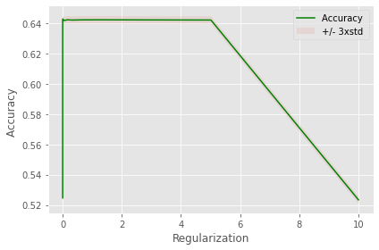

```
The best accuracy was with 0.6428165018605916 C= 0.01
```

```python
plt.plot(C,mean_acc,'g')
plt.fill_between(C,mean_acc - 1 * std_acc,mean_acc + 1 * std_acc, alpha=0.10)
plt.legend(('Accuracy ', '+/- 3xstd'))
plt.ylabel('Accuracy ')
plt.xlabel('Regularization')
plt.tight_layout()
plt.show()


best_c = C[mean_acc.argmax()]
print( "The best accuracy was with", mean_acc.max(), "C=", best_c)
```

```python
from sklearn.metrics import log_loss
LR = LogisticRegression(C=0.01 , solver='liblinear').fit(X_train,y_train)
lr_yhat = LR.predict(X_test)
yhat_prob = LR.predict_proba(X_test)
log_loss(y_test, yhat_prob)
```

```
0.6085578323148951
```

```python
print (classification_report(y_test, lr_yhat))
```

```
              precision    recall  f1-score   support

           1       0.70      0.94      0.80     22321
           2       0.65      0.23      0.34     11576

    accuracy                           0.69     33897
   macro avg       0.67      0.58      0.57     33897
weighted avg       0.68      0.69      0.64     33897
```

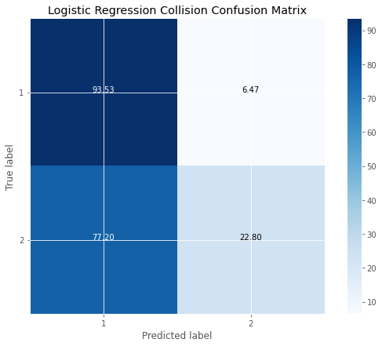

```python
import itertools
test_results = np.unique(y_test)
lr_confusion_matrix = confusion_matrix(y_test, lr_yhat, test_results)
title = 'Logistic Regression Collision Confusion Matrix'
cmap = plt.cm.Blues

plt.figure(figsize=(8, 6))
lr_confusion_matrix = (
    lr_confusion_matrix.astype('float') / lr_confusion_matrix.sum(axis=1)[:, np.newaxis]
    ) * 100

plt.imshow(lr_confusion_matrix, interpolation='nearest', cmap=cmap)
plt.title(title)
plt.colorbar()
tick_marks = np.arange(len(test_results))
plt.xticks(tick_marks, test_results)
plt.yticks(tick_marks, test_results)

fmt = '.2f'
thresh = lr_confusion_matrix.max() / 2.
for i, j in itertools.product(range(lr_confusion_matrix.shape[0]), range(lr_confusion_matrix.shape[1])):
    plt.text(j, i, format(lr_confusion_matrix[i, j], fmt),
             horizontalalignment="center",
             color="white" if lr_confusion_matrix[i, j] > thresh else "black")

plt.tight_layout()
plt.ylabel('True label')
plt.xlabel('Predicted label')

plt.show()
```

### Random Forest Classifier

```python
# Random Forest
from sklearn.ensemble import RandomForestClassifier
ests = 150
mean_acc = np.zeros((ests-1))
std_acc = np.zeros((ests-1))
ConfustionMx = []
for n in range(1,ests):
    print(n, end=' ')
    #Train Model and Predict
    rfc = RandomForestClassifier(n_estimators=n, max_depth=7, n_jobs=6).fit(X_train, y_train)
    yhat=rfc.predict(X_test)
    mean_acc[n-1] = accuracy_score(y_test, yhat)


    std_acc[n-1]=np.std(yhat==y_test)/np.sqrt(yhat.shape[0])

mean_acc
```

```
1 2 3 4 5 6 7 8 9 10 11 12 13 14 15 16 17 18 19 20 21 22 23 24 25 26 27 28 29 30 31 32 33 34 35 36 37 38 39 40 41 42 43 44 45 46 47 48 49 50 51 52 53 54 55 56 57 58 59 60 61 62 63 64 65 66 67 68 69 70 71 72 73 74 75 76 77 78 79 80 81 82 83 84 85 86 87 88 89 90 91 92 93 94 95 96 97 98 99 100 101 102 …
```

```
array([0.66377556, 0.71023984, 0.6910346 , 0.70723073, 0.70044547,
       0.7117444 , 0.71147889, 0.70631619, 0.71118388, 0.70684721,
       0.70366109, 0.70717173, 0.71000384, 0.7064047 , 0.70743724,
       0.70708322, 0.70994483, 0.70495914, 0.7038676 , 0.70829277,
       0.70982683, 0.70731923, 0.71015134, 0.70546066, 0.70433962,
       0.70560817, 0.71109538, 0.70242204, 0.70675871, 0.70708322,
       0.6986164 , 0.70959082, 0.69545978, 0.70566717, 0.7116854 ,
       0.70678821, 0.70962032, 0.71009234, 0.70976783, 0.7090303 ,
       0.71023984, 0.70186152, 0.70693572, 0.71094787, 0.71029885,
       0.71035785, 0.70578517, 0.70749624, 0.70726023, 0.70894179,
       0.70684721, 0.7063752 , 0.70997433, 0.70808626, 0.70236304,
       0.70596218, 0.7064047 , 0.71080037, 0.70773225, 0.70681771,
       0.70947281, 0.70950232, 0.70195003, 0.70767325, 0.70634569,
       0.70230404, 0.70723073, 0.70696522, 0.70469363, 0.71035785,
       0.7090303 , 0.70442812, 0.71280644, 0.70619819, 0.70439862,
       0.70994483, 0.7090008 , 0.70705372, 0.71023984, 0.70726023,
       0.701419  , 0.7090598 , 0.70728973, 0.70531315, 0.70770275,
       0.70723073, 0.70298256, 0.70967932, 0.70731923, 0.70823377,
       0.7064637 , 0.71059386, 0.70790925, 0.70728973, 0.70746674,
       0.70852878, 0.70758474, 0.70218603, 0.70608018, 0.70770275,
       0.70823377, 0.70525415, 0.70534266, 0.70566717, 0.70820427,
       0.70802726, 0.70475263, 0.7064637 , 0.70879429, 0.70608018,
       0.70734873, 0.70761424, 0.70979733, 0.70342508, 0.7012125 ,
       0.70602118, 0.70770275, 0.70726023, 0.70864678, 0.70575567,
       0.70608018, 0.70782075, 0.70799776, 0.70068148, 0.70554916,
       0.70997433, 0.70094699, 0.70790925, 0.70422161, 0.70770275,
       0.70557866, 0.7089713 , 0.70894179, 0.70817476, 0.70782075,
       0.70755524, 0.70501814, 0.70867628, 0.7090598 , 0.70852878,
       0.70758474, 0.70726023, 0.70787975, 0.70823377, 0.70723073,
       0.70876479, 0.70826327, 0.70923681, 0.70855828])
```

```
The best accuracy was with 0.7128064430480574 with n = 73
```

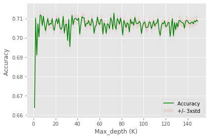

```python
plt.plot(range(1,ests),mean_acc,'g')
plt.fill_between(range(1,ests),mean_acc - 1 * std_acc,mean_acc + 1 * std_acc, alpha=0.10)
plt.legend(('Accuracy ', '+/- 3xstd'))
plt.ylabel('Accuracy ')
plt.xlabel('Max_depth (K)')
plt.tight_layout()
rfc_best_n = mean_acc.argmax()+1
print("The best accuracy was with", mean_acc.max(), "with n =", rfc_best_n)
plt.show()
```

```python
rfc = RandomForestClassifier(n_estimators=rfc_best_n).fit(X_train, y_train)
rfc_yhat = rfc.predict(X_test)
print(classification_report(y_test, rfc_yhat))
```

```
              precision    recall  f1-score   support

           1       0.74      0.80      0.77     22321
           2       0.53      0.45      0.49     11576

    accuracy                           0.68     33897
   macro avg       0.63      0.62      0.63     33897
weighted avg       0.67      0.68      0.67     33897
```

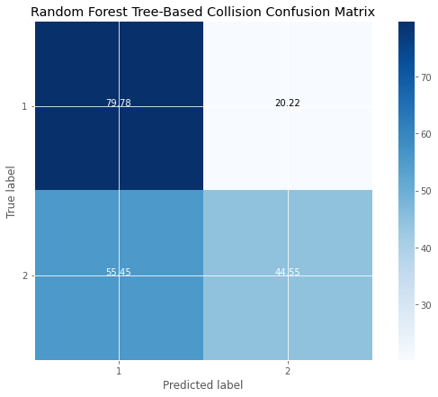

```python
test_results = np.unique(y_test)
rfc_confusion_matrix = confusion_matrix(y_test, rfc_yhat, test_results)
title = 'Random Forest Tree-Based Collision Confusion Matrix'
cmap = plt.cm.Blues

plt.figure(figsize=(8, 6))
rfc_confusion_matrix = (
    rfc_confusion_matrix.astype('float') / rfc_confusion_matrix.sum(axis=1)[:, np.newaxis]
    ) * 100

plt.imshow(rfc_confusion_matrix, interpolation='nearest', cmap=cmap)
plt.title(title)
plt.colorbar()
tick_marks = np.arange(len(test_results))
plt.xticks(tick_marks, test_results)
plt.yticks(tick_marks, test_results)

fmt = '.2f'
thresh = rfc_confusion_matrix.max() / 2.
for i, j in itertools.product(range(rfc_confusion_matrix.shape[0]), range(rfc_confusion_matrix.shape[1])):
    plt.text(j, i, format(rfc_confusion_matrix[i, j], fmt),
             horizontalalignment="center",
             color="white" if rfc_confusion_matrix[i, j] > thresh else "black")

plt.tight_layout()
plt.ylabel('True label')
plt.xlabel('Predicted label')

plt.show()
```

```python
from sklearn.metrics import jaccard_score
from sklearn.metrics import f1_score
from sklearn.metrics import log_loss
```

### Generate Samples using imblearn's SMOTE [1]

```python
from imblearn.over_sampling import SMOTE
#new split in train and test use smote on train_smote fraction
X_train_smote, X_test_smote, y_train_smote, y_test_smote = train_test_split(values, results, test_size=0.2, random_state=27)
sm=SMOTE()

X_train_smote, y_train_smote=sm.fit_sample(X_train_smote, y_train_smote)
print ('Train set:', X_train_smote.shape,  y_train_smote.shape)
print ('Test set:', X_test_smote.shape,  y_test_smote.shape)
```

```
Train set: (178216, 34) (178216,)
Test set: (33897, 34) (33897,)
```

```python
#SMOTE and RFC

ests = 150
mean_acc = np.zeros((ests-1))
std_acc = np.zeros((ests-1))
ConfustionMx = []
for n in range(1,ests):
    print(n, end=' ')
    #Train Model and Predict
    rfc = RandomForestClassifier(n_estimators=n, max_depth=7, n_jobs=6).fit(X_train_smote, y_train_smote)
    rfc_smote_yhat=rfc.predict(X_test_smote)
    mean_acc[n-1] = accuracy_score(y_test_smote, rfc_smote_yhat)


    std_acc[n-1]=np.std(rfc_smote_yhat==y_test_smote)/np.sqrt(rfc_smote_yhat.shape[0])

mean_acc
```

```
1 2 3 4 5 6 7 8 9 10 11 12 13 14 15 16 17 18 19 20 21 22 23 24 25 26 27 28 29 30 31 32 33 34 35 36 37 38 39 40 41 42 43 44 45 46 47 48 49 50 51 52 53 54 55 56 57 58 59 60 61 62 63 64 65 66 67 68 69 70 71 72 73 74 75 76 77 78 79 80 81 82 83 84 85 86 87 88 89 90 91 92 93 94 95 96 97 98 99 100 101 102 …
```

```
array([0.63247485, 0.63828657, 0.62515857, 0.65672478, 0.65471871,
       0.65560374, 0.6260141 , 0.63793256, 0.61769478, 0.64628138,
       0.64819896, 0.62914122, 0.63259285, 0.6286987 , 0.65209311,
       0.62778417, 0.62981975, 0.62480455, 0.63197333, 0.62427353,
       0.64232823, 0.63244535, 0.63749004, 0.63256335, 0.64262324,
       0.63610349, 0.63271086, 0.64722542, 0.62374251, 0.64970351,
       0.62654512, 0.62155943, 0.62244446, 0.636251  , 0.62722365,
       0.62415553, 0.6234475 , 0.65589875, 0.63197333, 0.6312063 ,
       0.62551258, 0.63415642, 0.65427619, 0.62521757, 0.63843408,
       0.6389356 , 0.62695814, 0.62784317, 0.62648612, 0.62238546,
       0.6414727 , 0.64448181, 0.6312653 , 0.6286397 , 0.62754816,
       0.62990825, 0.62377202, 0.62728265, 0.62728265, 0.62769567,
       0.62920022, 0.62430304, 0.62675163, 0.63029177, 0.62757766,
       0.63049827, 0.63480544, 0.62324099, 0.63828657, 0.62713514,
       0.63731304, 0.62669263, 0.62507007, 0.62489306, 0.62704664,
       0.6234475 , 0.63878809, 0.62775467, 0.62686963, 0.62636812,
       0.6388766 , 0.64374428, 0.6284922 , 0.62766617, 0.6261026 ,
       0.62430304, 0.6623005 , 0.62633861, 0.62896422, 0.62740065,
       0.62778417, 0.62946573, 0.62831519, 0.62462755, 0.62619111,
       0.62276898, 0.63875859, 0.62819719, 0.62409653, 0.62704664,
       0.62799068, 0.62704664, 0.6312948 , 0.62772517, 0.62701714,
       0.63046877, 0.62796118, 0.62692864, 0.62616161, 0.62796118,
       0.6285807 , 0.62725315, 0.6286987 , 0.62654512, 0.62748916,
       0.62504056, 0.62689914, 0.62790217, 0.62790217, 0.62645662,
       0.62400802, 0.62834469, 0.62648612, 0.62775467, 0.6337139 ,
       0.62943623, 0.62645662, 0.62769567, 0.6259551 , 0.63244535,
       0.62719415, 0.63153081, 0.62471605, 0.6284627 , 0.62273948,
       0.63132431, 0.62512907, 0.62548308, 0.6284922 , 0.62810868,
       0.6258666 , 0.62819719, 0.62297548, 0.62781367, 0.62093991,
       0.6337434 , 0.62672213, 0.62315249, 0.62775467])
```

```
The best accuracy was with 0.6623004985691949 with n = 87
```

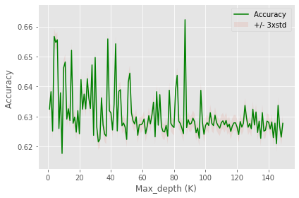

```python
plt.plot(range(1,ests),mean_acc,'g')
plt.fill_between(range(1,ests),mean_acc - 1 * std_acc,mean_acc + 1 * std_acc, alpha=0.10)
plt.legend(('Accuracy ', '+/- 3xstd'))
plt.ylabel('Accuracy ')
plt.xlabel('Max_depth (K)')
plt.tight_layout()
rfc_best_n_smote = mean_acc.argmax()+1
print("The best accuracy was with", mean_acc.max(), "with n =", rfc_best_n_smote)
plt.show()
```

```python
rfc_smote = RandomForestClassifier(n_estimators=rfc_best_n_smote).fit(X_train_smote, y_train_smote)
rfc_yhat_smote = rfc_smote.predict(X_test_smote)
print(classification_report(y_test_smote, rfc_yhat_smote))
```

```
              precision    recall  f1-score   support

           1       0.74      0.71      0.72     22075
           2       0.50      0.53      0.51     11822

    accuracy                           0.65     33897
   macro avg       0.62      0.62      0.62     33897
weighted avg       0.65      0.65      0.65     33897
```

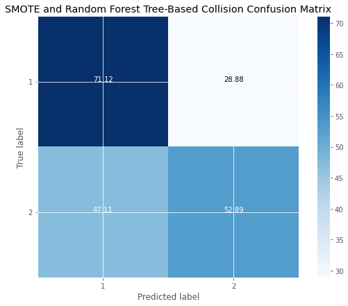

```python
test_results = np.unique(y_test)
rfc_confusion_matrix = confusion_matrix(y_test_smote, rfc_yhat_smote, test_results)
title = 'SMOTE and Random Forest Tree-Based Collision Confusion Matrix'
cmap = plt.cm.Blues

plt.figure(figsize=(8, 6))
rfc_confusion_matrix = (
    rfc_confusion_matrix.astype('float') / rfc_confusion_matrix.sum(axis=1)[:, np.newaxis]
    ) * 100

plt.imshow(rfc_confusion_matrix, interpolation='nearest', cmap=cmap)
plt.title(title)
plt.colorbar()
tick_marks = np.arange(len(test_results))
plt.xticks(tick_marks, test_results)
plt.yticks(tick_marks, test_results)

fmt = '.2f'
thresh = rfc_confusion_matrix.max() / 2.
for i, j in itertools.product(range(rfc_confusion_matrix.shape[0]), range(rfc_confusion_matrix.shape[1])):
    plt.text(j, i, format(rfc_confusion_matrix[i, j], fmt),
             horizontalalignment="center",
             color="white" if rfc_confusion_matrix[i, j] > thresh else "black")

plt.tight_layout()
plt.ylabel('True label')
plt.xlabel('Predicted label')

plt.show()
```

### Logistic Regresssion with SMOTE

```python
C = np.power(10, np.linspace(-5,1,21))

mean_acc = np.zeros(len(C))
std_acc = np.zeros(len(C))

for n, c in enumerate(C):

    #Train Model and Predict
    LR_smote = LogisticRegression(C=c, solver='liblinear').fit(X_train_smote, y_train_smote)
    yhat_smote = LR_smote.predict(X_test_smote)
    mean_acc[n-1] = f1_score(y_test_smote, yhat_smote, average='weighted')
    std_acc[n-1]=np.std(yhat_smote==y_test_smote)/np.sqrt(yhat_smote.shape[0])

mean_acc
```

```
array([0.62378404, 0.62337055, 0.62463737, 0.6248007 , 0.62563008,
       0.6289039 , 0.62895675, 0.62912976, 0.62925414, 0.62981918,
       0.62960615, 0.62960023, 0.62975343, 0.62967391, 0.62999757,
       0.63046876, 0.63080713, 0.63071668, 0.6307416 , 0.63085698,
       0.6272185 ])
```

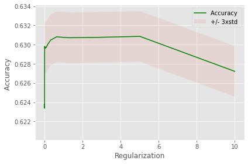

```
The best accuracy was with 0.6308569837472189 C= 5.011872336272725
```

```python
plt.plot(C,mean_acc,'g')
plt.fill_between(C,mean_acc - 1 * std_acc,mean_acc + 1 * std_acc, alpha=0.10)
plt.legend(('Accuracy ', '+/- 3xstd'))
plt.ylabel('Accuracy ')
plt.xlabel('Regularization')
plt.tight_layout()
plt.show()


best_c = C[mean_acc.argmax()]
print( "The best accuracy was with", mean_acc.max(), "C=", best_c)
```

```python
LR_smote = LogisticRegression(C=best_c, solver='liblinear').fit(X_train_smote, y_train_smote)
lr_yhat_smote = LR.predict(X_test_smote)
yhat_prob_smote = LR.predict_proba(X_test_smote)
log_loss(y_test_smote, yhat_prob_smote)
```

```
0.6119197084616842
```

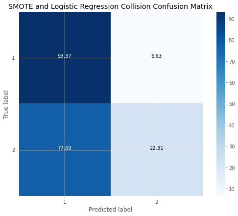

```python
test_results = np.unique(y_test)
lr_confusion_matrix = confusion_matrix(y_test_smote, lr_yhat_smote, test_results)
title = 'SMOTE and Logistic Regression Collision Confusion Matrix'
cmap = plt.cm.Blues

plt.figure(figsize=(8, 6))
lr_confusion_matrix = (
    lr_confusion_matrix.astype('float') / lr_confusion_matrix.sum(axis=1)[:, np.newaxis]
    ) * 100

plt.imshow(lr_confusion_matrix, interpolation='nearest', cmap=cmap)
plt.title(title)
plt.colorbar()
tick_marks = np.arange(len(test_results))
plt.xticks(tick_marks, test_results)
plt.yticks(tick_marks, test_results)

fmt = '.2f'
thresh = lr_confusion_matrix.max() / 2.
for i, j in itertools.product(range(lr_confusion_matrix.shape[0]), range(lr_confusion_matrix.shape[1])):
    plt.text(j, i, format(lr_confusion_matrix[i, j], fmt),
             horizontalalignment="center",
             color="white" if lr_confusion_matrix[i, j] > thresh else "black")

plt.tight_layout()
plt.ylabel('True label')
plt.xlabel('Predicted label')

plt.show()
```

```python
print(classification_report(y_test_smote, lr_yhat_smote))
```

```
              precision    recall  f1-score   support

           1       0.69      0.93      0.79     22075
           2       0.64      0.22      0.33     11822

    accuracy                           0.69     33897
   macro avg       0.67      0.58      0.56     33897
weighted avg       0.67      0.69      0.63     33897
```

### BalancedRandom Forest Classifier

```python
from imblearn.ensemble import BalancedRandomForestClassifier
ests = 150
mean_acc = np.zeros((ests-1))
std_acc = np.zeros((ests-1))
ConfustionMx = []
for n in range(1,ests):
    print(n, end=' ')
    #Train Model and Predict
    brfc = BalancedRandomForestClassifier(n_estimators=n, max_depth=7, n_jobs=6).fit(X_train, y_train)
    brfc_yhat=brfc.predict(X_test)
    mean_acc[n-1] = accuracy_score(y_test, brfc_yhat)


    std_acc[n-1]=np.std(brfc_yhat==y_test)/np.sqrt(brfc_yhat.shape[0])

mean_acc
```

```
1 2 3 4 5 6 7 8 9 10 11 12 13 14 15 16 17 18 19 20 21 22 23 24 25 26 27 28 29 30 31 32 33 34 35 36 37 38 39 40 41 42 43 44 45 46 47 48 49 50 51 52 53 54 55 56 57 58 59 60 61 62 63 64 65 66 67 68 69 70 71 72 73 74 75 76 77 78 79 80 81 82 83 84 85 86 87 88 89 90 91 92 93 94 95 96 97 98 99 100 101 102 …
```

```
array([0.62731215, 0.64734342, 0.66716819, 0.62840369, 0.62563059,
       0.58842965, 0.6259846 , 0.6441278 , 0.62902322, 0.63011476,
       0.61796029, 0.65645927, 0.65111957, 0.64123669, 0.61884533,
       0.62380152, 0.6156592 , 0.61878632, 0.6259551 , 0.6261026 ,
       0.623359  , 0.65893737, 0.62235596, 0.62235596, 0.63949612,
       0.62061539, 0.62825619, 0.62819719, 0.64542585, 0.64958551,
       0.64575036, 0.62362451, 0.6181078 , 0.63341889, 0.62642712,
       0.61869782, 0.62551258, 0.65274213, 0.62209045, 0.62442104,
       0.6466354 , 0.62459805, 0.6285807 , 0.63586748, 0.63530696,
       0.6312063 , 0.62504056, 0.64280025, 0.62315249, 0.62241496,
       0.65294864, 0.62058589, 0.65409918, 0.63445143, 0.62123492,
       0.64250524, 0.6182848 , 0.62394902, 0.61878632, 0.62315249,
       0.64816945, 0.62695814, 0.62117592, 0.62760716, 0.62509957,
       0.62058589, 0.63335988, 0.62651562, 0.62005487, 0.6155707 ,
       0.62173644, 0.62542408, 0.62365401, 0.62164793, 0.62176594,
       0.62474555, 0.61881582, 0.62002537, 0.62902322, 0.62238546,
       0.62554208, 0.62622061, 0.62878721, 0.6234475 , 0.62515857,
       0.62406703, 0.62566009, 0.62459805, 0.6208514 , 0.61993687,
       0.62627961, 0.63796206, 0.62772517, 0.63102929, 0.6284627 ,
       0.62675163, 0.62713514, 0.63020326, 0.62132342, 0.62291648,
       0.62545358, 0.6285807 , 0.62232646, 0.61928784, 0.6233    ,
       0.63271086, 0.62250347, 0.62182494, 0.61899283, 0.62002537,
       0.61999587, 0.62114641, 0.62247397, 0.62442104, 0.6338024 ,
       0.61984836, 0.61990737, 0.62141192, 0.62141192, 0.62282798,
       0.62456855, 0.61804879, 0.6233885 , 0.62226746, 0.61934684,
       0.62695814, 0.63533646, 0.61990737, 0.62545358, 0.62214945,
       0.62356551, 0.6233295 , 0.61925834, 0.63471694, 0.6208219 ,
       0.62102841, 0.61899283, 0.61884533, 0.63046877, 0.62055639,
       0.62034988, 0.62450954, 0.62206095, 0.62034988, 0.62226746,
       0.62563059, 0.6208809 , 0.62377202, 0.62633861])
```

```
The best accuracy was with 0.66716818597516 with n = 3
```

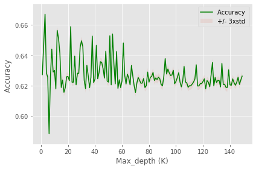

```python
plt.plot(range(1,ests),mean_acc,'g')
plt.fill_between(range(1,ests),mean_acc - 1 * std_acc,mean_acc + 1 * std_acc, alpha=0.10)
plt.legend(('Accuracy ', '+/- 3xstd'))
plt.ylabel('Accuracy ')
plt.xlabel('Max_depth (K)')
plt.tight_layout()
brfc_best_n = mean_acc.argmax()+1
print("The best accuracy was with", mean_acc.max(), "with n =", brfc_best_n)
plt.show()
```

```python
brfc = BalancedRandomForestClassifier(n_estimators=brfc_best_n).fit(X_train, y_train)
brfc_yhat = brfc.predict(X_test)
print(classification_report(y_test, brfc_yhat))
```

```
              precision    recall  f1-score   support

           1       0.75      0.61      0.68     22321
           2       0.45      0.61      0.52     11576

    accuracy                           0.61     33897
   macro avg       0.60      0.61      0.60     33897
weighted avg       0.65      0.61      0.62     33897
```

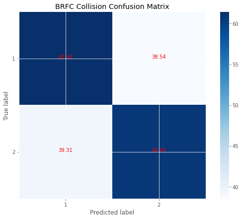

```python
test_results = np.unique(y_test)
brfc_confusion_matrix = confusion_matrix(y_test, brfc_yhat, test_results)
title = 'BRFC Collision Confusion Matrix'
cmap = plt.cm.Blues

plt.figure(figsize=(8, 6))
brfc_confusion_matrix = (
    brfc_confusion_matrix.astype('float') / brfc_confusion_matrix.sum(axis=1)[:, np.newaxis]
    ) * 100

plt.imshow(brfc_confusion_matrix, interpolation='nearest', cmap=cmap)
plt.title(title)
plt.colorbar()
tick_marks = np.arange(len(test_results))
plt.xticks(tick_marks, test_results)
plt.yticks(tick_marks, test_results)

fmt = '.2f'
thresh = brfc_confusion_matrix.max() / 2.
for i, j in itertools.product(range(brfc_confusion_matrix.shape[0]), range(brfc_confusion_matrix.shape[1])):
    plt.text(j, i, format(brfc_confusion_matrix[i, j], fmt),
             horizontalalignment="center",
             color="red" if brfc_confusion_matrix[i, j] > thresh else "black")

plt.tight_layout()
plt.ylabel('True label')
plt.xlabel('Predicted label')

plt.show()
```